# **Capstone project: Data-driven suggestions for HR**

# Evaluate Model Performance

```python
def get_metric_name(metric):
    return f"{metric}".split("=")[0].replace("<function","").split("at")[0].strip()
```

```python
def eval_model(model,model_name,results_df=pd.DataFrame(),show_cm=False):
    """
    Takes a model, its name/description, and a dataframe.
    Returns a dataframe with evaulation results, option to display a confusion matrix.
    """
    eval_results = {}
    eval_results["model_name"] = model_name
    y_pred = model.predict(x_test)
    for metric in [metrics.accuracy_score,metrics.precision_score,metrics.recall_score,metrics.f1_score]:
            eval_results[get_metric_name(metric)]=[round(metric(y_test,y_pred),3)]
    if show_cm:
        cm= metrics.confusion_matrix(y_test,y_pred,labels=model.classes_)
        disp= metrics.ConfusionMatrixDisplay(cm,display_labels=model.classes_)
        disp.plot()
        plt.title(f"{model_name} Confusion Matrix")
        plt.show()
    return pd.concat([results_df,pd.DataFrame(eval_results)],axis=0)
```

Init Results DF

```python
results_dict={}
for metric in [metrics.accuracy_score,metrics.precision_score,metrics.recall_score,metrics.f1_score]:
            results_dict[get_metric_name(metric)]=[]
results_df=pd.DataFrame(results_dict)
results_df.head()
```

|  | accuracy_score | precision_score | recall_score | f1_score |
| --- | --- | --- | --- | --- |

```python
#display metrics
#TODO: display is janky, put in one row, fix naming
model_suite = {"LogisticRegressor":model_logreg,"XGBoost Classifier":xbg_cv.best_estimator_,"Random Forest Classifier":rclf_cv.best_estimator_}
for model_name,model in model_suite.items():
    results_df=eval_model(model,model_name,results_df)
results_df.sort_values(by=[f"{refit}_score"],ascending=False)
```

|  | accuracy_score | precision_score | recall_score | f1_score | model_name |
| --- | --- | --- | --- | --- | --- |
| 0 | 0.980 | 0.953 | 0.922 | 0.937 | XGBoost Classifier |
| 0 | 0.981 | 0.981 | 0.905 | 0.941 | Random Forest Classifier |
| 0 | 0.829 | 0.461 | 0.178 | 0.257 | LogisticRegressor |

💭

### Reflect on these questions as you complete the executing stage.

- What key insights emerged from your model(s)?
- What business recommendations do you propose based on the models built?
- What potential recommendations would you make to your manager/company?
- Do you think your model could be improved? Why or why not? How?
- Given what you know about the data and the models you were using, what other questions could you address for the team?
- What resources do you find yourself using as you complete this stage? (Make sure to include the links.)
- Do you have any ethical considerations in this stage?

# Champion Model Results and Evaluation

- Interpret model
- Evaluate model performance using metrics
- Prepare results, visualizations, and actionable steps to share with stakeholders

### Measuring top model against holdout set

```python
#measure best model against Test set
top_model_name = results_df.sort_values(by=[f"{refit}_score"],ascending=False)["model_name"].iloc[0]
model_final = model_suite[top_model_name]
model_final
```

```
XGBClassifier(base_score=None, booster=None, callbacks=None,
              colsample_bylevel=None, colsample_bynode=None,
              colsample_bytree=0.7, device=None, early_stopping_rounds=None,
              enable_categorical=False, eval_metric=None, feature_types=None,
              gamma=None, grow_policy=None, importance_type=None,
              interaction_constraints=None, learning_rate=0.2, max_bin=None,
              max_cat_threshold=None, max_cat_to_onehot=None,
              max_delta_step=None, max_depth=np.int64(3), max_leaves=None,
              min_child_weight=np.int64(2), missing=nan,
              monotone_constraints=None, multi_strategy=None,
              n_estimators=np.int64(125), n_jobs=-1, num_parallel_tree=None,
              random_state=42, ...)
```

### Inspect Model feature importance

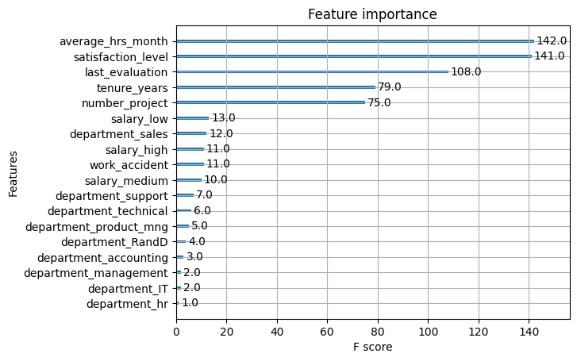

```python
plot_importance(model_final)
plt.show()
```

## EDA From Model Insights: XGBoost

The SHAP libary is most likely to give us the insight we need to assess importance via impact.

```python
# initialize shap
import shap
shap.initjs()
```

```python
# get explainer
explainer = shap.Explainer(model_final,algorithm="tree")
shap_values = explainer(x_train)
# verify shape
print(shap_values.shape)
```

```
(7194, 20)
```

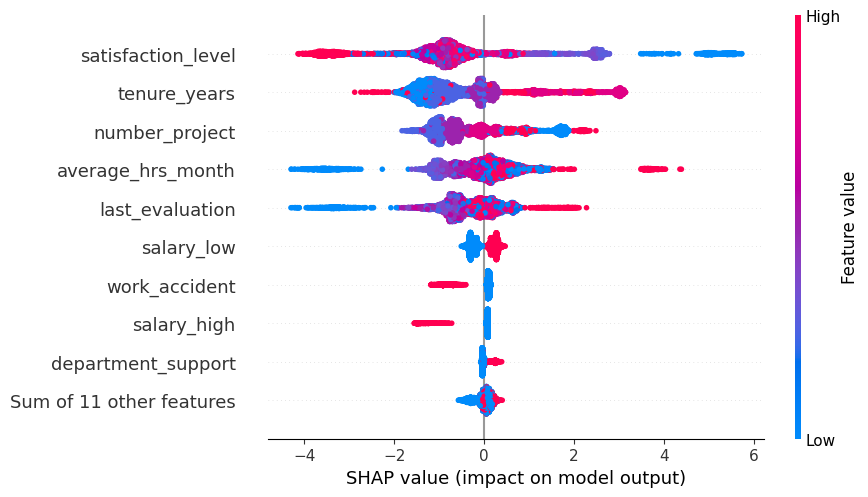

```python
shap.plots.beeswarm(shap_values)
```

Let's examine how these were used to make a judgment, using sample at index 2 from the training data.

```python
success_dict = {1:'left',0:'stayed'}
print(f"With 'left' value of {str(bool(y_train[2])).lower()}, their data would indicate that employee #2 {success_dict[int(y_train[2])]}.")
```

```
With 'left' value of true, their data would indicate that employee #2 left.
```

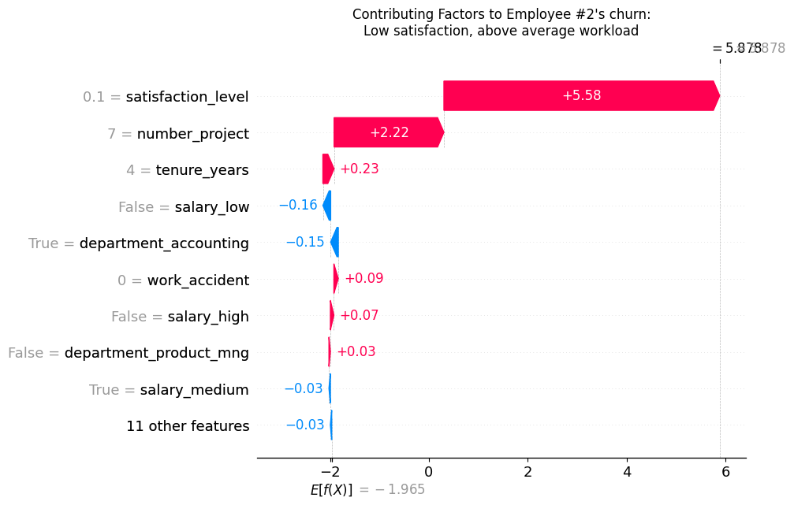

```python
shap.plots.waterfall(shap_values[2],show=False)
plt.title("Contributing Factors to Employee #2's churn:\nLow satisfaction, above average workload")
plt.show()
```